# Practical Machine Learning Course Project

Amit

12 Jul 2018

## Project Description

One thing that people regularly do is quantify how much of a particular activity they do, but they rarely quantify how well they do it. In this project, we use data from accelerometers on the belt, forearm, arm, and dumbell of 6 participants to predict the manner in which they did the exercise.

## Data Processing

We read the provdied Training and Testing csv files into R and examine a few sample rows to understand the variables.

```r
suppressPackageStartupMessages(library(caret))
suppressPackageStartupMessages(library(rattle))

download.file("https://d396qusza40orc.cloudfront.net/predmachlearn/pml-training.csv","../course8project/pml-training.csv")
download.file("https://d396qusza40orc.cloudfront.net/predmachlearn/pml-testing.csv","../course8project/pml-testing.csv")

pmlData <- read.csv("../course8project/pml-Training.csv",na.strings=c("", "NA"))
pmlTest <- read.csv("../course8project/pml-Testing.csv",na.strings=c("", "NA"))

#Examine a few rows
head(pmlData,2)
head(pmlTest,2)

#For columns with NA, what is the proportin of missing data?
unique(colSums(is.na(pmlData))/nrow(pmlData))

#Check for any other zero variance variables
nearZeroVar(pmlData,saveMetrics=TRUE)
```

[output not shown]

We can now clean the data as below:

1. We see that for columns which contain missing values, the values are missing on about 98% of the rows. We remove such variables.
2. Column 6 new_window is ‘no’ on 98% of the rows. Where this value ‘yes’, additional information appears in variables which are already removed in above step.
3. Column 1 is just aserial number and need not be included in the prediction model.

```r
#remove columns with NA
pmlData <- pmlData[,colSums(is.na(pmlData))==0]
pmlTest <- pmlTest[,colSums(is.na(pmlTest))==0]

#Remove column 1 and new_window
pmlData <- pmlData[,-c(1,6)]
pmlTest <- pmlTest[,-c(1,6)]
```

Let’s check if we have the same column names in train and test. Only difference is classe in Train and problem_id in Test.

```r
setdiff(names(pmlData), names(pmlTest))
```

```
## [1] "classe"
```

```r
setdiff(names(pmlTest), names(pmlData))
```

```
## [1] "problem_id"
```

## Data slicing for training and validation

We slice our Training dataset further into 75:25 ratio for training and validating our model.

```r
#set overall seed for reproducible results
set.seed(1234)

inTrain <- createDataPartition(y=pmlData$classe,p=0.75,list=FALSE)
training <- pmlData[inTrain,]
validation <- pmlData[-inTrain,]

dim(training)
```

```
## [1] 14718    58
```

```r
dim(validation)
```

```
## [1] 4904   58
```

## Prediction Algorithms

### Let us try Classification Trees with 5-fold cross validation

```r
fit_ct <- train(classe~., data=training, method="rpart",
                trControl=trainControl(method="cv", 5))
fit_ct
```

```
## CART
##
## 14718 samples
##    57 predictor
##     5 classes: 'A', 'B', 'C', 'D', 'E'
##
## No pre-processing
## Resampling: Cross-Validated (5 fold)
## Summary of sample sizes: 11773, 11775, 11774, 11776, 11774
## Resampling results across tuning parameters:
##
##   cp          Accuracy   Kappa
##   0.04310263  0.4714100  0.31405727
##   0.04538118  0.4229767  0.22020238
##   0.11535175  0.3318945  0.07241762
##
## Accuracy was used to select the optimal model using the largest value.
## The final value used for the model was cp = 0.04310263.
```

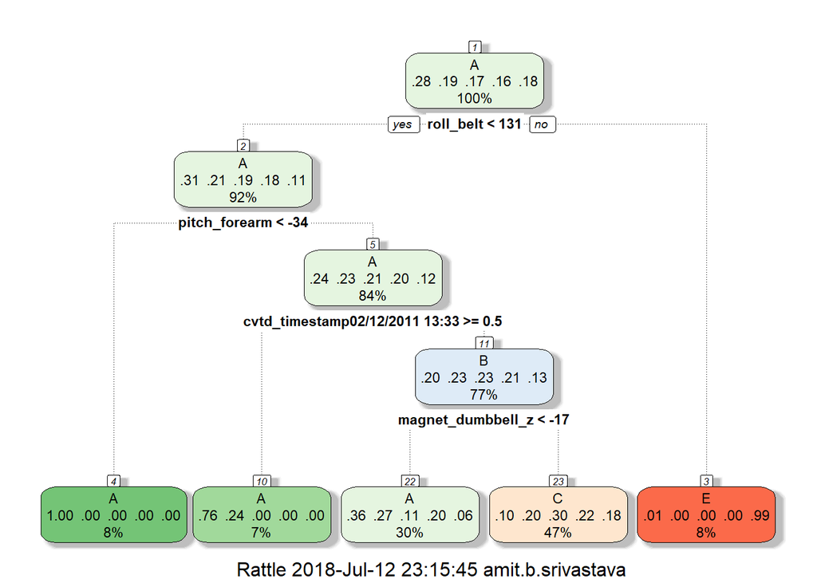

```r
fancyRpartPlot(fit_ct$finalModel)
```

### Let us now try boosting with trees with 5-fold cross validation. This model should work well with large number of predictors.

```r
fit_gbm <- train(classe~., data=training, method="gbm",
                trControl=trainControl(method="cv", 5), verbose=FALSE)
fit_gbm
```

```
## Stochastic Gradient Boosting
##
## 14718 samples
##    57 predictor
##     5 classes: 'A', 'B', 'C', 'D', 'E'
##
## No pre-processing
## Resampling: Cross-Validated (5 fold)
## Summary of sample sizes: 11776, 11773, 11775, 11773, 11775
## Resampling results across tuning parameters:
##
##   interaction.depth  n.trees  Accuracy   Kappa
##   1                   50      0.8406706  0.7977249
##   1                  100      0.9000537  0.8734263
##   1                  150      0.9268233  0.9072999
##   2                   50      0.9576020  0.9463157
##   2                  100      0.9872264  0.9838417
##   2                  150      0.9922540  0.9902022
##   3                   50      0.9835576  0.9791966
##   3                  100      0.9936129  0.9919209
##   3                  150      0.9969424  0.9961326
##
## Tuning parameter 'shrinkage' was held constant at a value of 0.1
##
## Tuning parameter 'n.minobsinnode' was held constant at a value of 10
## Accuracy was used to select the optimal model using the largest value.
## The final values used for the model were n.trees = 150,
##  interaction.depth = 3, shrinkage = 0.1 and n.minobsinnode = 10.
```

In sample error rate for the model is 0.32%. We will now validate our model with our validation dataset.

```r
pred_gbm <- predict(fit_gbm, validation)
confusionMatrix(validation$classe, pred_gbm)
```

```
## Confusion Matrix and Statistics
##
##           Reference
## Prediction    A    B    C    D    E
##          A 1395    0    0    0    0
##          B    1  945    3    0    0
##          C    0    1  846    8    0
##          D    0    0    2  801    1
##          E    0    0    0    1  900
##
## Overall Statistics
##
##                Accuracy : 0.9965
##                  95% CI : (0.9945, 0.998)
##     No Information Rate : 0.2847
##     P-Value [Acc > NIR] : < 2.2e-16
##
##                   Kappa : 0.9956
##  Mcnemar's Test P-Value : NA
##
## Statistics by Class:
##
##                      Class: A Class: B Class: C Class: D Class: E
## Sensitivity            0.9993   0.9989   0.9941   0.9889   0.9989
## Specificity            1.0000   0.9990   0.9978   0.9993   0.9998
## Pos Pred Value         1.0000   0.9958   0.9895   0.9963   0.9989
## Neg Pred Value         0.9997   0.9997   0.9988   0.9978   0.9998
## Prevalence             0.2847   0.1929   0.1735   0.1652   0.1837
## Detection Rate         0.2845   0.1927   0.1725   0.1633   0.1835
## Detection Prevalence   0.2845   0.1935   0.1743   0.1639   0.1837
## Balanced Accuracy      0.9996   0.9990   0.9960   0.9941   0.9993
```

### Let us try Random Forests with 5-fold cross validation

```r
fit_rf <- train(classe~., data=training, method="rf",
                trControl=trainControl(method="cv", 5))
fit_rf
```

```
## Random Forest
##
## 14718 samples
##    57 predictor
##     5 classes: 'A', 'B', 'C', 'D', 'E'
##
## No pre-processing
## Resampling: Cross-Validated (5 fold)
## Summary of sample sizes: 11774, 11773, 11774, 11776, 11775
## Resampling results across tuning parameters:
##
##   mtry  Accuracy   Kappa
##    2    0.9881099  0.9849569
##   40    0.9987089  0.9983668
##   79    0.9983013  0.9978513
##
## Accuracy was used to select the optimal model using the largest value.
## The final value used for the model was mtry = 40.
```

```r
pred_rf <- predict(fit_rf, validation)
confusionMatrix(validation$classe, pred_rf)
```

```
## Confusion Matrix and Statistics
##
##           Reference
## Prediction    A    B    C    D    E
##          A 1395    0    0    0    0
##          B    0  949    0    0    0
##          C    0    1  852    2    0
##          D    0    0    0  804    0
##          E    0    0    0    0  901
##
## Overall Statistics
##
##                Accuracy : 0.9994
##                  95% CI : (0.9982, 0.9999)
##     No Information Rate : 0.2845
##     P-Value [Acc > NIR] : < 2.2e-16
##
##                   Kappa : 0.9992
##  Mcnemar's Test P-Value : NA
##
## Statistics by Class:
##
##                      Class: A Class: B Class: C Class: D Class: E
## Sensitivity            1.0000   0.9989   1.0000   0.9975   1.0000
## Specificity            1.0000   1.0000   0.9993   1.0000   1.0000
## Pos Pred Value         1.0000   1.0000   0.9965   1.0000   1.0000
## Neg Pred Value         1.0000   0.9997   1.0000   0.9995   1.0000
## Prevalence             0.2845   0.1937   0.1737   0.1644   0.1837
## Detection Rate         0.2845   0.1935   0.1737   0.1639   0.1837
## Detection Prevalence   0.2845   0.1935   0.1743   0.1639   0.1837
## Balanced Accuracy      1.0000   0.9995   0.9996   0.9988   1.0000
```

Accuracy for the model with our validation dataset is 99.94% and Out of sample error rate is 0.06%.

## Conclusion

Though Randon Forests takes much longer to build the model, accuracy is very high and better than Gradient Boosting Method. We use this model to predict on given testing data.

```r
pred <- predict(fit_rf, pmlTest)
results <- cbind.data.frame(pmlTest$problem_id,pred)
names(results) <- c('Problem ID', 'Predicted Classe')
results
```

```
##    Problem ID Predicted Classe
## 1           1                B
## 2           2                A
## 3           3                B
## 4           4                A
## 5           5                A
## 6           6                E
## 7           7                D
## 8           8                B
## 9           9                A
## 10         10                A
## 11         11                B
## 12         12                C
## 13         13                B
## 14         14                A
## 15         15                E
## 16         16                E
## 17         17                A
## 18         18                B
## 19         19                B
## 20         20                B
```